# Statistics in R: Descriptive Statistics

⇦ Back

**Descriptive statistics** do exactly what they say on the box: they *describe* the data you are working with. They are also known as *summary statistics*.

Take a look at the following dataset:

```r
data <- data.frame(
    x = c(10, 8, 13, 9, 11, 14, 6, 4, 12, 7, 5),
    y = c(8.04, 6.95, 7.58, 8.81, 8.33, 9.96, 7.24, 4.26, 10.84, 4.82, 5.68)
)
```

Visualise it by printing it in a table and plotting it:

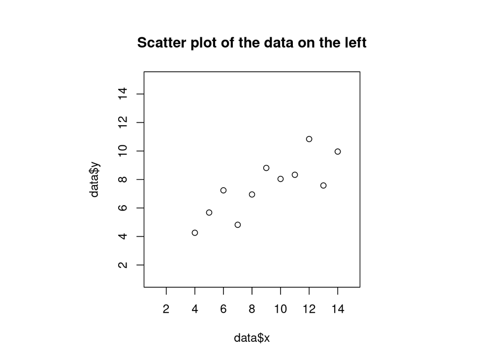

| x | y |
| --- | --- |
| 10 | 8.04 |
| 8 | 6.95 |
| 13 | 7.58 |
| 9 | 8.81 |
| 11 | 8.33 |
| 14 | 9.96 |
| 6 | 7.24 |
| 4 | 4.26 |
| 12 | 10.84 |
| 7 | 4.82 |
| 5 | 5.68 |

```r
library(kableExtra)

kable_input <- kable(data)
kable_styling(
    kable_input, full_width = F, position = "float_left",
    bootstrap_options = c("responsive", "hover", "striped", "condensed")
)
par(pin = c(3, 3))
plot(
    data$x, data$y, main = "Scatter plot of the data on the left",
    xlim = c(1, 15), ylim = c(1, 15)
)
```

## Summary Statistics

Examples of “summary data” that you might be interested in include mean, median, minimum, maximum and quartiles. These can all be calculated by calling the `summary()` function:

```r
summary(data)
```

```
##        x              y
##  Min.   : 4.0   Min.   : 4.260
##  1st Qu.: 6.5   1st Qu.: 6.315
##  Median : 9.0   Median : 7.580
##  Mean   : 9.0   Mean   : 7.501
##  3rd Qu.:11.5   3rd Qu.: 8.570
##  Max.   :14.0   Max.   :10.840
```

This is nice to see but we can’t use those pieces of information while they are in that format. To access each of those values individually we need to extract them using indexing:

```r
summary <- summary(data$x)

min <- summary[1]
first_q <- summary[2]
median <- summary[3]
mean <- summary[4]
third_q <- summary[5]
max <- summary[6]

print(paste(min, first_q, median, mean, third_q, max, sep = "; "))
```

```
## [1] "4; 6.5; 9; 9; 11.5; 14"
```

Alternatively, we can calculate them individually instead of using the `summary()` function (which calculates them all together):

```r
min <- min(data$x)
first_q <- quantile(data$x, 0.25)
median <- median(data$x)
mean <- mean(data$x)
third_q <- quantile(data$x, 0.75)
max <- max(data$x)

print(paste(min, first_q, median, mean, third_q, max, sep = "; "))
```

```
## [1] "4; 6.5; 9; 9; 11.5; 14"
```

## Line of Best Fit

As we’ve already plotted a scatter plot we might as well add a line of best fit! And if we do that we might as well also calculate its gradient and y-intercept. The coefficient of determination (R<sup>2</sup>) of this linear regression might also be relevant. All of these things can be done with the linear model function `lm()`:

```r
# Note that you specify the y-data first and the x-data second, separated by a
# tilde (~):
lm(data$y ~ data$x)
```

```
##
## Call:
## lm(formula = data$y ~ data$x)
##
## Coefficients:
## (Intercept)       data$x
##      3.0001       0.5001
```

Now you can extract the coefficients you want using the `summary()` function and indexing:

```r
# Extract the y-intercept
summary(lm(data$y ~ data$x))$coefficients[1]
# Extract the gradient
summary(lm(data$y ~ data$x))$coefficients[2]
# Extract the r-squared value
summary(lm(data$y ~ data$x))$r.squared
```

```
## [1] 3.000091
## [1] 0.5000909
## [1] 0.6665425
```

This is what the data looks like with the line of best fit added in:

| x | y |
| --- | --- |
| 10 | 8.04 |
| 8 | 6.95 |
| 13 | 7.58 |
| 9 | 8.81 |
| 11 | 8.33 |
| 14 | 9.96 |
| 6 | 7.24 |
| 4 | 4.26 |
| 12 | 10.84 |
| 7 | 4.82 |
| 5 | 5.68 |

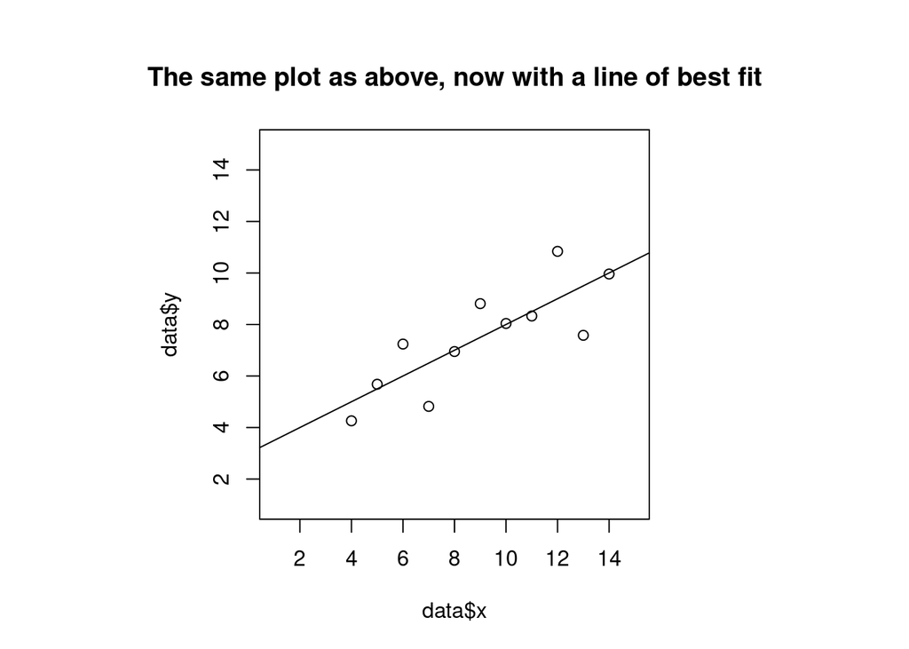

```r
par(pin = c(3, 3))
plot(
    data$x, data$y,
    main = "The same plot as above, now with a line of best fit",
    xlim = c(1, 15), ylim = c(1, 15)
)
abline(lm(data$y ~ data$x), col = "black")
```

# Anscombe’s quartet

Be careful when looking at descriptive statistics because they can hide a lot of information about a dataset. This is well demonstrated by something called “[Anscombe’s quartet](https://en.wikipedia.org/wiki/Anscombe%27s_quartet)” which is a series of four datasets (of which the above dataset is one) that all have very similar descriptive statistics despite being vastly different. Have a look below:

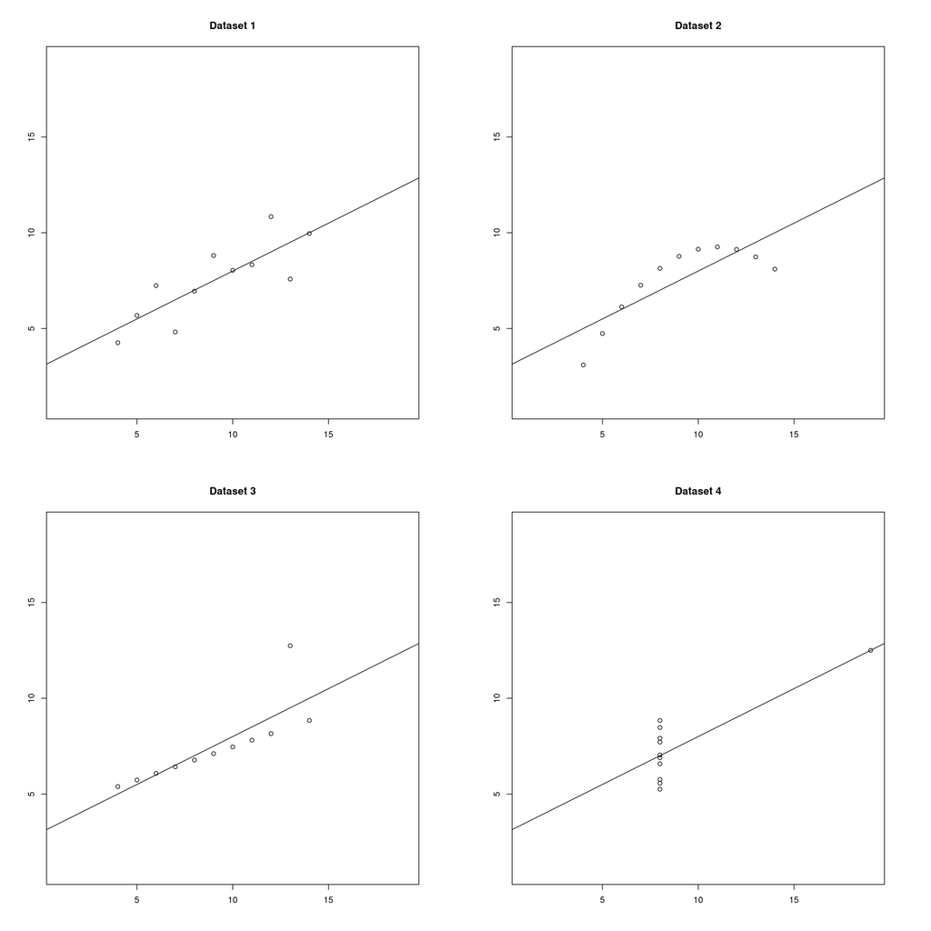

```r
anscombes_quartet <- list(
    I = list(
        c(10, 8, 13, 9, 11, 14, 6, 4, 12, 7, 5),
        c(8.04, 6.95, 7.58, 8.81, 8.33, 9.96, 7.24, 4.26, 10.84, 4.82, 5.68)
    ),
    II = list(
        c(10, 8, 13, 9, 11, 14, 6, 4, 12, 7, 5),
        c(9.14, 8.14, 8.74, 8.77, 9.26, 8.1, 6.13, 3.1, 9.13, 7.26, 4.74)
    ),
    III = list(
        c(10, 8, 13, 9, 11, 14, 6, 4, 12, 7, 5),
        c(7.46, 6.77, 12.74, 7.11, 7.81, 8.84, 6.08, 5.39, 8.15, 6.42, 5.73)
    ),
    IV = list(
        c(8, 8, 8, 8, 8, 8, 8, 19, 8, 8, 8),
        c(6.58, 5.76, 7.71, 8.84, 8.47, 7.04, 5.25, 12.5, 5.56, 7.91, 6.89)
    )
)
par(pin = c(6, 6), mfrow = c(2, 2))
for (i in 1:4) {
    dataset <- anscombes_quartet[[i]]
    x <- dataset[[1]]
    y <- dataset[[2]]
    plot(
        x, y, main = sprintf("Dataset %s", i), xlim = c(1, 19),
        ylim = c(1, 19), xlab = "", ylab = ""
    )
    abline(lm(data$y ~ data$x), col = "black")
}
```

These are quite clearly four very different scatter plots, yet their descriptive statistics are surprisingly similar:

```r
for (i in 1:4) {
    dataset <- anscombes_quartet[[i]]
    x <- dataset[[1]]
    y <- dataset[[2]]
    print(sprintf("Mean of x: %s", mean(x)))
    print(sprintf("Sample variance of x: %s", var(x)))
    print(sprintf("Mean of y: %.2f", mean(y)))
    print(sprintf("Sample variance of y: %.2f", var(y)))
    print(sprintf("Correlation between x and y: %.3f", cor(x, y)))
    linear_model <- lm(y ~ x)
    print(
        sprintf(
            "Linear regression line: y = %.2f + %.3fx",
            coef(linear_model)["(Intercept)"],
            coef(linear_model)["x"]
        )
    )
    print(
        sprintf(
            "Coefficient of determination: %.2f",
            summary(linear_model)$r.squared
        )
    )
    cat("\n")
}
```

| Property | Value | Accuracy |
| --- | --- | --- |
| Mean of x | 9 | exact |
| Sample variance of x: $\sigma ^{2}$ | 11 | exact |
| Mean of y | 7.50 | to 2 decimal places |
| Sample variance of y: $\sigma ^{2}$ | 4.125 | ± 0.003 |
| Correlation btwn x and y | 0.816 | to 3 decimal places |
| Linear regression line | y = 3.00 + 0.500x | to 2 and 3 decimal places, respectively |
| Coefficient of determination of the linear regression: $R^{2}$ | 0.67 | to 2 decimal places |

⇦ Back